# Testing Project Analysis Report

Automated Report by Climmob

07 October, 2019

You are reading a report generated by ClimMob. This is a software package to analyze data generated by citizen science or crowdsourcing.

# Introduction

In agriculture, the local environmental conditions determine to a large degree which technological solutions are the most suitable. In dry soils, for example, drought-resistant crop varieties will outperform other varieties, but in wet soils these same varieties may do worse than most. Not only drought, but an entire range of problems including excessive heat, floods, new pests and diseases tend to intensify under climate change. This multitude of limiting factors requires multiple technological solutions, tested in diverse environments.

Citizen science is based on the cooperation of citizen scientist or observers (paid or unpaid). Researchers assign microtasks (observations, experiments…) that, once completed and gathered, contribute with a great amount of information to science. One of the advantages of citizen science is that agricultural researchers can get access to many environments by crowdsourcing their experiments. As farmers contribute with their time, skills and knowledge to the investigation, researchers are able to do more tests than in a traditional setup. Also citizen scientists acquire new knowledge, abilities and information useful for future challenges of their work.

**ClimMob**

The primary goal of ClimMob is to help farmers adapt to variable and changing climates. ClimMob was created as part of Bioversity International’s research in the CGIAR Research Programme on Climate Change, Agriculture, and Food Security (CCAFS). It serves to prepare and analyze citizen science experiments in which a large number of farmers observe and compare different technological options under a wide range environmental conditions (van Etten 2011).

ClimMob software assigns a limited number of items (typically 3 crop varieties or agricultural practices) to each farmer, who will compare their performance. Each farmer gets a different combination of items drawn from a much larger set of items. Comparisons of this kind are thought to be a very reliable way to obtain data from human observers (Martin 2004). Once the results of the microtasks have been collected, ClimMob builds an image of the whole set of assigned objects, combining all observations. ClimMob not only reconstructs the overall ordering of items, but also takes into account differences and similarities between observers and the conditions under which they observe. It assigns similar observers to groups that each corresponds to a different preference profile. Groups are created on the basis of whichever variables which have been collected, that are found to be significantly linked to the preferences.

ClimMob uses a recently published statistical method to analyze ranking data (Strobl et al. 2011). It automatically generates analytical reports, as well as individualized information sheets for each participant.

**How to cite**

If you publish any results generated with ClimMob, you should cite a number of articles as the package builds on various contributions. Van Etten (2011) introduced the crowdsourcing philosophy behind ClimMob. It is important to mention that ClimMob is implemented in R, a free, open-source analysis software (R Development Core Team 2012). Methodologically, if you report on the tree results, you should mentioned that ClimMob applies the Bradley-Terry tree method published by Strobl et al. (2011). To cite ClimMob itself, mention Van Etten & Calderer (2015).

# Section 1: Headline Results

Overall there were 150 farmers participating in this study. Each farmer assessed three different varieties and ranked them in order of their overall preference. In addition they also provided rankings for 3 additional traits:

| Short name | Question |
| --- | --- |
| difficult | What dance is the most difficult? |
| style | What dance looks the best? |
| fun | What dance is the most fun? |

Table 1 provides a list of the varieties assessed within this trial, with the frequency and percentage of farmers who assessed each variety.

Table 1: Frequency of varieties Assessed

| Variety | Frequency | % of Respondents | Man (n=102) | Woman (n=46) |
| --- | --- | --- | --- | --- |
| Ballroom | 64 | 43% | 40 | 23 |
| Hip Hop | 65 | 43% | 44 | 21 |
| Morris Dancing | 64 | 43% | 43 | 20 |
| Rave | 64 | 43% | 40 | 23 |
| Rumba | 64 | 43% | 46 | 17 |
| Salsa | 65 | 43% | 48 | 16 |
| Tap | 64 | 43% | 45 | 18 |

## Overall Differences in Rankings

Overall there were no statistically significant differences found in the rankings of varieties in the overall ranking (p=0.19737 )

A summary of the p-values testing the hypothesis that there exist differences in the rankings within each of the Plackett-Luce models fitted for each of the assessed traits, and the list of varieties which were significantly highest and lowest ranked overall, are summarised in Table 1.1.

Table 1.1: Summary of Differences Found In varieties by Trait

[output not shown]

## Effect of covariates

None of the variables tested were found to have a statistically significant relationship to the overall ranking at the 5 % significance level.

A summary of the univariate signifance levels for all covariates that were able to be tested is shown in Table 1.2.1.

Table 1.2.1: Summary of univariate p-values for first split in Plackett-Luce tree model for the overall ranking

| Variable | p |
| --- | --- |
| age | 0.29448 |
| gender | 0.99079 |

## Relationships between traits

Table 1.3 shows, for each trait in the study, the frequency with which the rankings matched with the overall ranking.

The trait(s) which had the strongest relationship with the overall ranking was difficult. Overall the rankings for difficult matched the rankings for the overall ranking 29.7% of the time.

The trait(s) which had the weakest relationship with the overall ranking was fun. Overall the rankings for fun matched the rankings for the overall ranking only 19.4% of the time.

Table 1.3: Relationship between individual trait assessment and overall assesment

| trait | Complete Ranking Agreement |
| --- | --- |
| fun | 19% |
| style | 20% |
| difficult | 30% |

# Section 2: Data Summary and Exploratory Analysis of Traits

## Assessment of varieties

### Overall

Overall performance of each of the varieties is summarised in Table 2.1.

Table 2.1 - Summary of Overall Performance

| Variety | N | % Top Ranked | % Bottom Ranked | % Contests Won | Net Favourability Score |
| --- | --- | --- | --- | --- | --- |
| Rumba | 62 | 45.2% | 21.0% | 62.1% | 24.2 |
| Rave | 64 | 40.6% | 31.2% | 54.7% | 9.4 |
| Morris Dancing | 63 | 28.6% | 28.6% | 50.0% | 0.0 |
| Ballroom | 64 | 28.1% | 32.8% | 47.7% | -4.7 |
| Salsa | 63 | 31.7% | 36.5% | 47.6% | -4.8 |
| Tap | 62 | 33.9% | 41.9% | 46.0% | -8.1 |
| Hip Hop | 63 | 25.4% | 41.3% | 42.1% | -15.9 |

This shows the % of farmers who assessed the variety as their most preferred of the 3 varieties they were provided, the % of farmers who included the variety as their least preferred, the % of ‘head to head contests’ for which the variety won and the net favourability score. A score of +100 indicates the variety won all ‘contests’ it was involved in, a score of 0 indicates an equal number of wins and losses, a score of -100 indicates the variety lost all contests.

*Figure 2.1*

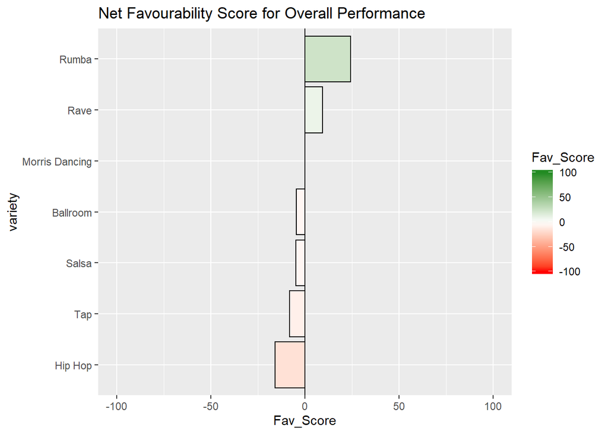

The variety Rumba was the most preferred variety overall being ranked highest by 45.2% of the 62 farmers who assessed this variety.

### Other Traits

Net favourability scores are shown below for the other traits assessed in this study.

**What dance is the most difficult?**

Table 2.2.1: Favourability Statistics for difficult

| variety | N | % Top Ranked | % Bottom Ranked | % Contests Won | Net Favourability Score |
| --- | --- | --- | --- | --- | --- |
| Rumba | 61 | 45.9% | 32.8% | 56.6% | 13.1 |
| Morris Dancing | 63 | 39.7% | 28.6% | 55.6% | 11.1 |
| Ballroom | 63 | 31.7% | 30.2% | 50.8% | 1.6 |
| Tap | 61 | 32.8% | 32.8% | 50.0% | 0.0 |
| Salsa | 61 | 34.4% | 36.1% | 49.2% | -1.6 |
| Rave | 63 | 23.8% | 31.7% | 46.0% | -7.9 |
| Hip Hop | 63 | 25.4% | 41.3% | 42.1% | -15.9 |

*Figure 2.2.1*

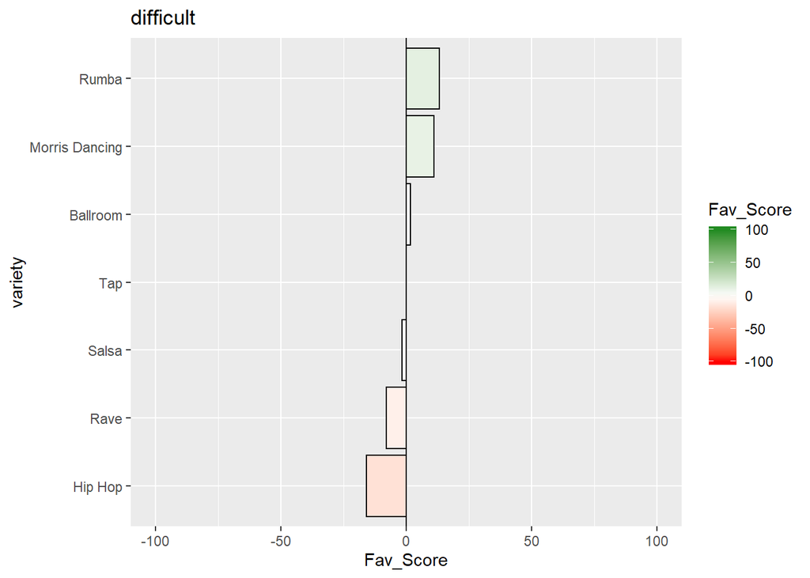

**What dance looks the best?**

Table 2.2.2: Favourability Statistics for style

| variety | N | % Top Ranked | % Bottom Ranked | % Contests Won | Net Favourability Score |
| --- | --- | --- | --- | --- | --- |
| Tap | 60 | 33.3% | 26.7% | 53.3% | 6.7 |
| Rave | 61 | 39.3% | 34.4% | 52.5% | 4.9 |
| Ballroom | 61 | 31.1% | 26.2% | 52.5% | 4.9 |
| Morris Dancing | 61 | 31.1% | 34.4% | 48.4% | -3.3 |
| Rumba | 59 | 37.3% | 40.7% | 48.3% | -3.4 |
| Hip Hop | 62 | 29.0% | 33.9% | 47.6% | -4.8 |
| Salsa | 59 | 32.2% | 37.3% | 47.5% | -5.1 |

*Figure 2.2.2*

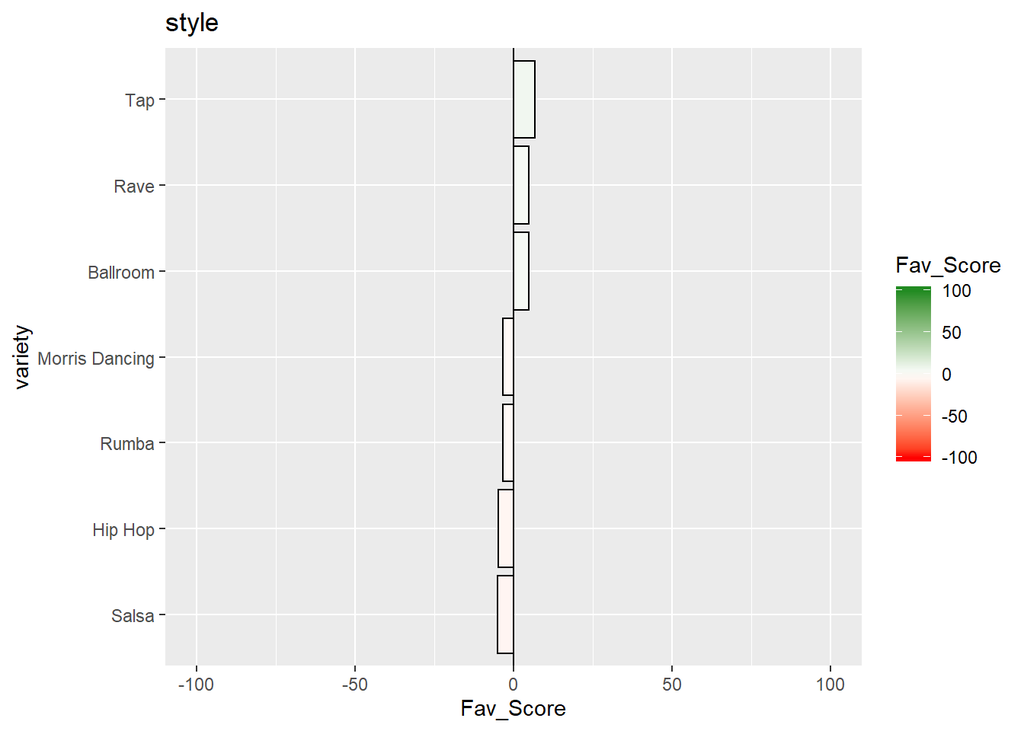

**What dance is the most fun?**

Table 2.2.3: Favourability Statistics for fun

| variety | N | % Top Ranked | % Bottom Ranked | % Contests Won | Net Favourability Score |
| --- | --- | --- | --- | --- | --- |
| Rumba | 59 | 39.0% | 25.4% | 56.8% | 13.6 |
| Tap | 58 | 41.4% | 29.3% | 56.0% | 12.1 |
| Hip Hop | 61 | 34.4% | 26.2% | 54.1% | 8.2 |
| Morris Dancing | 60 | 40.0% | 35.0% | 52.5% | 5.0 |
| Ballroom | 61 | 32.8% | 41.0% | 45.9% | -8.2 |
| Salsa | 60 | 26.7% | 35.0% | 45.8% | -8.3 |
| Rave | 61 | 19.7% | 41.0% | 39.3% | -21.3 |

*Figure 2.2.3*

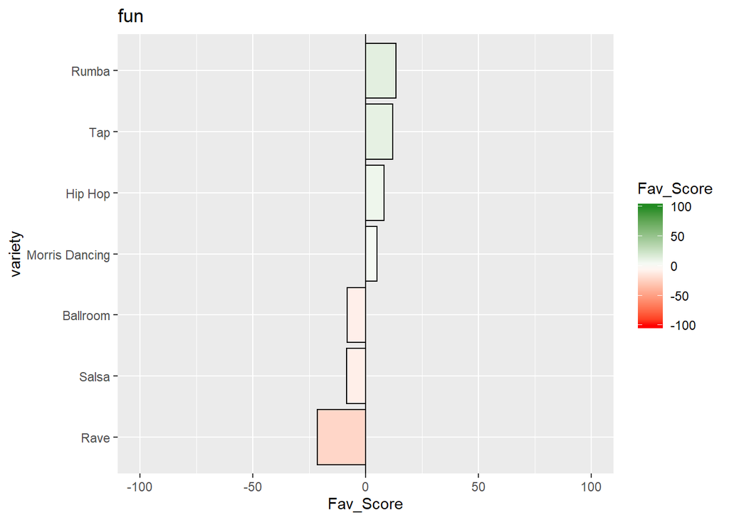

## Pairwise Contests

Appendix B contains the full data for each pairwise comparison of the varieties, which is summarised in the plots below.

### Overall

*Figure 2.3*

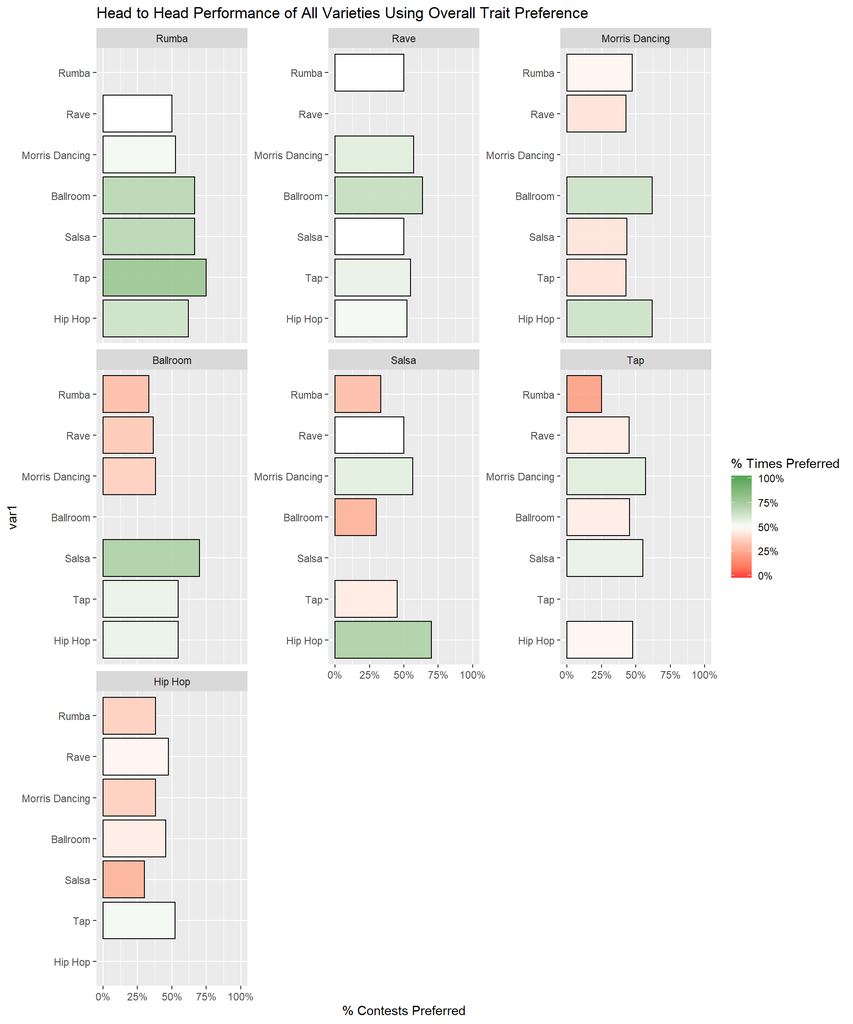

### Other Traits

Results from the pairwise contests of the other individual traits assessed are shown below.

**What dance is the most difficult?**

*Figure 2.4.1*

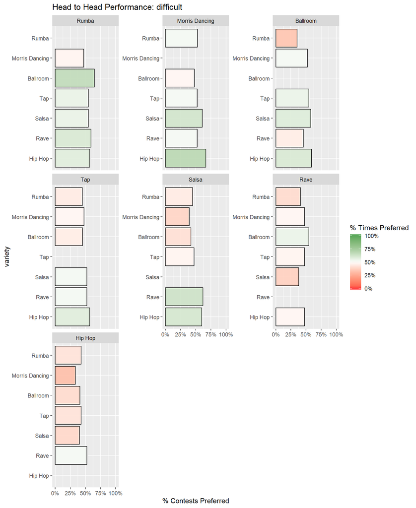

**What dance looks the best?**

*Figure 2.4.2*

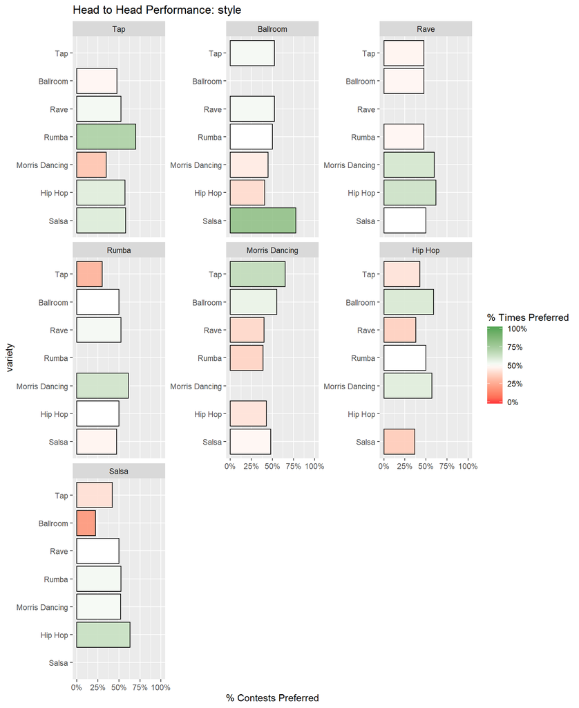

**What dance is the most fun?**

*Figure 2.4.3*

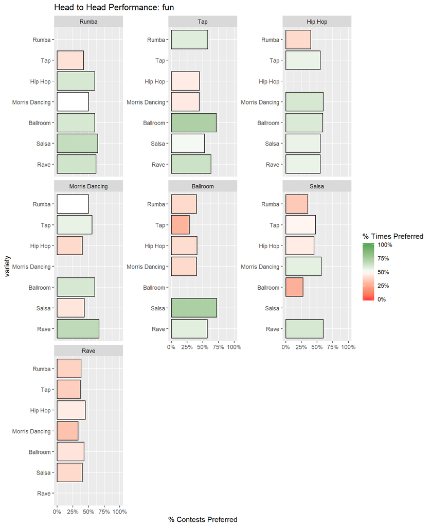

## Relationship between traits

Table 2.5 shows the relationship between the individual trait rankings and the overall rankings.  
Complete agreement represents the percentage of respondents for which the ranking of the three varieties in respect to the trait is an exact match to the overall ranking. Given that there are 6 possible ways of ranking the three varieties that each farmer assesses, it would be expected that, if there was no relationship between the ranking of the trait and the overall ranking, that the complete rankings would agree 17% of the time by chance. Best/worst agreement represents the percentage for which the best/worst variety for the trait matched the overall best/worst. Given that there are 3 possible varieties that each farmer assesses, it would be expected that, if there was no relationship between the ranking of the trait and the overall ranking, that the best/worst rankings would still agree 33% of the time by chance.

Table 2.5: Relationship between individual trait assessment and overall assessment

| trait | Complete Ranking Agreement | Agreement with Overall Best | Agreement with Overall Worst |
| --- | --- | --- | --- |
| fun | 19% | 37% | 39% |
| style | 20% | 32% | 32% |
| difficult | 30% | 45% | 39% |

*Figure 2.5*

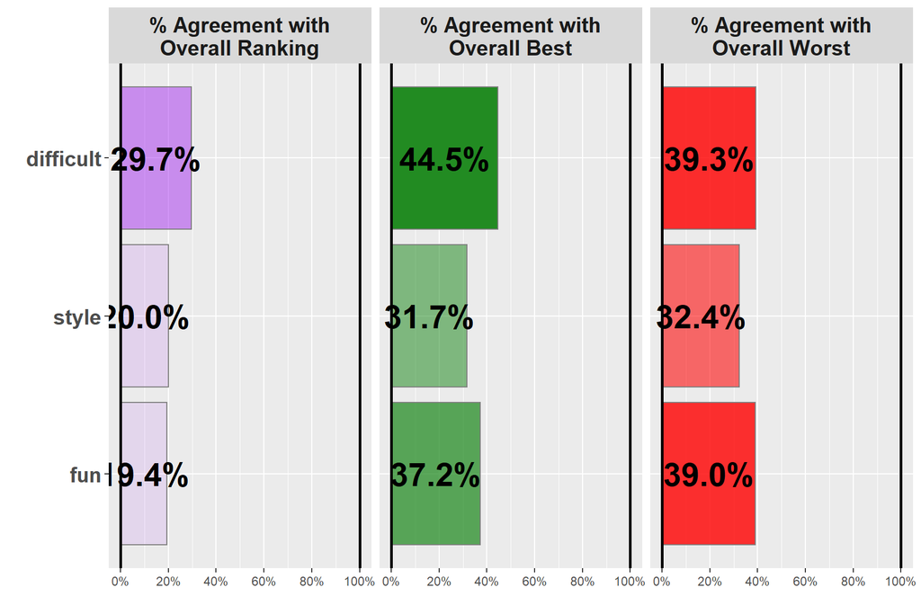

Overall the trait which had the strongest relationship with the overall ranking was difficult, with identical rankings being given as the overall ranking 30% of the time.

# Section 3: Data Summary & Exploratory Analysis of Covariates

## Location of farmers

*Figure 3.0*

No coordinates recorded in data

| Short name | Question |
| --- | --- |
| age | How old are you? |
| gender | What is the gender ? |

Tables 3.1.1 to 3.2.2 summarise the covariate data collected from the survey, with corresponding bar charts or histograms of the responses.

**age**

Table 3.1.1 Missing Values in age

| age | Freq | Percent |
| --- | --- | --- |
| Complete | 149 | 99.3% |
| Missing | 1 | 0.7% |

Table 3.1.2 Summary statistics for age

| Variable | gender | Mean | Median | Minimum | Maximum | Standard Deviation |
| --- | --- | --- | --- | --- | --- | --- |
| age | Man | 41.58 | 34 | 2 | 266 | 35.88 |
| age | Woman | 43.17 | 36 | 12 | 122 | 22.64 |
| age | Overall | 42.15 | 35 | 2 | 266 | 32.19 |

*Figure 3.1*

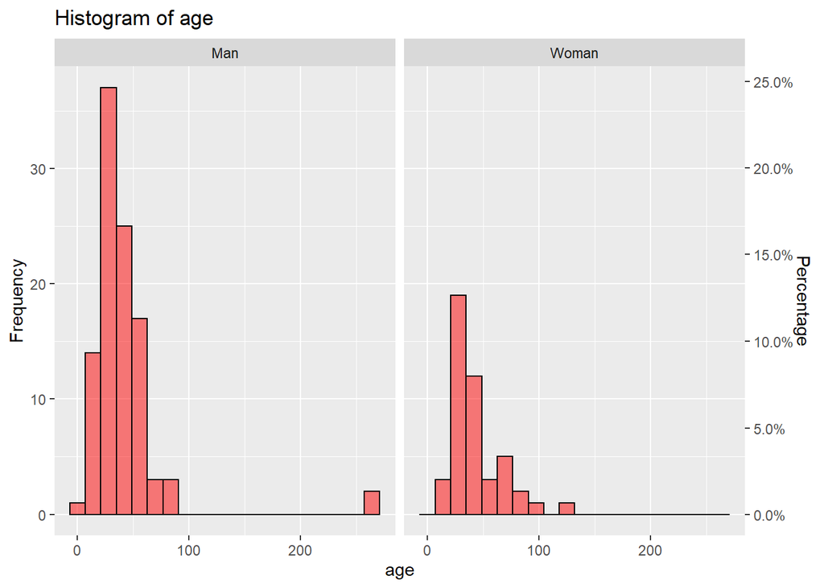

**gender**

Table 3.2.1 Missing Values in gender

| gender | Freq | Percent |
| --- | --- | --- |
| Complete | 148 | 98.7% |
| Missing | 2 | 1.3% |

Table 3.2.2 Summary statistics for gender

| gender | Frequency | % of Respondents |
| --- | --- | --- |
| Man | 102 | 69% |
| Woman | 46 | 31% |

*Figure 3.2*

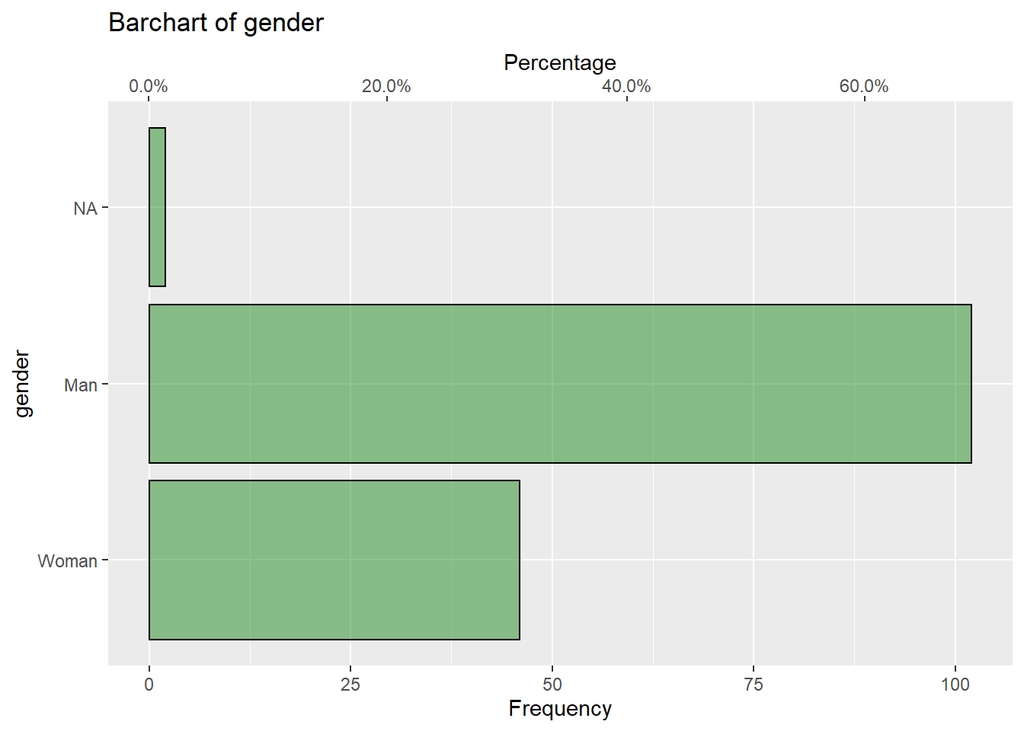

# Section 4: Plackett-Luce Models of Ranking Differences

## Overall Ranking

Table 4.1 shows the results from the likelihood ratio test from the Plackett-Luce model for overall rankings of the different varieties. The hypothesis being tested is that there is no difference in the assessments of any of the different varieties.

Table 4.1: Likelihood ratio test results from overall model

| model | logLikelihood | DF | Statistic | Pr(>Chisq) |
| --- | --- | --- | --- | --- |
| NULL | -263.3886 | 441 | NA | NA |
| mod_overall | -259.0887 | 435 | 8.599806 | 0.19737 |

p=0.19737. This suggests that there is not enough evidence to conclude that there are differences between varieties

*Figure 4.1 - Overall Ranking: Model Coefficients and Mean Separation*

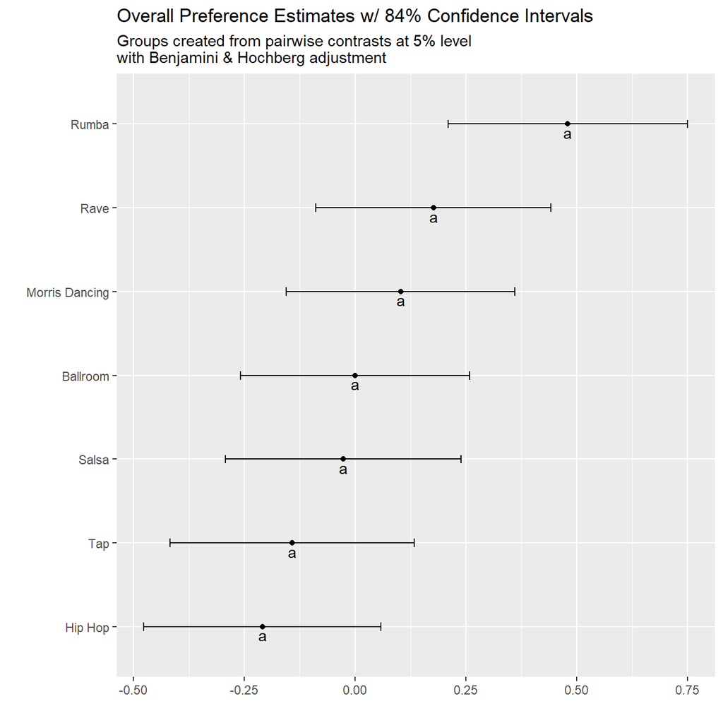

The same information as Figure 4.1 is shown in Table 4.2 below

Table 4.2 - Model Coefficients and Mean Separation of varieties at 5% Level with BH adjustment

|  | Estimate | quasiSE | Group |
| --- | --- | --- | --- |
| Rumba | 0.48 | 0.19 | a |
| Rave | 0.18 | 0.19 | a |
| Morris Dancing | 0.10 | 0.18 | a |
| Ballroom | 0.00 | 0.18 | a |
| Salsa | -0.03 | 0.19 | a |
| Tap | -0.14 | 0.20 | a |
| Hip Hop | -0.21 | 0.19 | a |

Table 4.3 and Figure 4.2 use the coefficients from the model to estimate the probability of each variety being considered to be the top ranked variety in a direct comparison between all of the possible varieties

Table 4.3: Percentage probability of being the highest ranked overall

|  | Variety | % Probability |
| --- | --- | --- |
| Rumba | Rumba | 21.3% |
| Rave | Rave | 15.8% |
| Morris Dancing | Morris Dancing | 14.6% |
| Ballroom | Ballroom | 13.2% |
| Salsa | Salsa | 12.9% |
| Tap | Tap | 11.5% |
| Hip Hop | Hip Hop | 10.7% |

*Figure 4.2 - Overall Ranking: Probability of Being The Highest Ranked Overall*

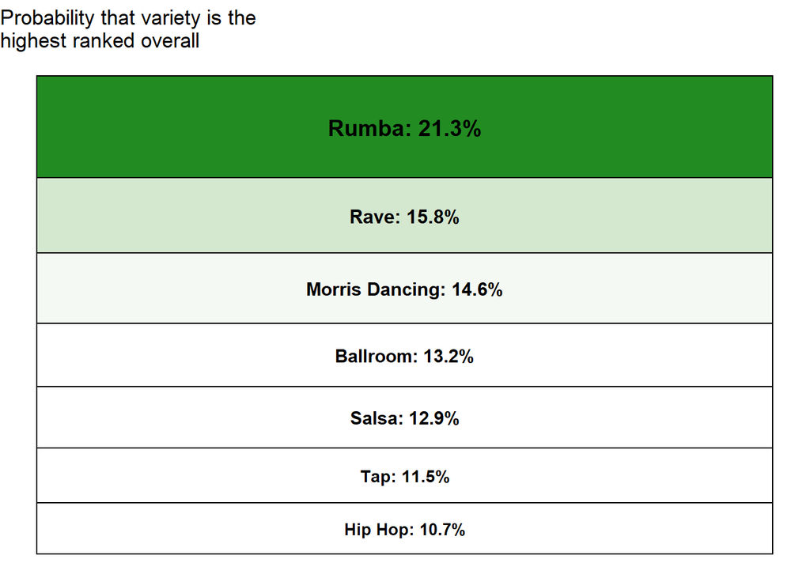

# Section 5: Plackett Luce Models Of Other Traits

**What dance is the most difficult?**

Table 5.1.1

| model | logLikelihood | DF | Statistic | Pr(>Chisq) |
| --- | --- | --- | --- | --- |
| NULL | -259.8051 | 435 | NA | NA |
| mod_difficult | -257.9817 | 429 | 3.646831 | 0.72434 |

p=0.72434 , this suggests that there is not enough evidence to conclude that there are differences between varieties

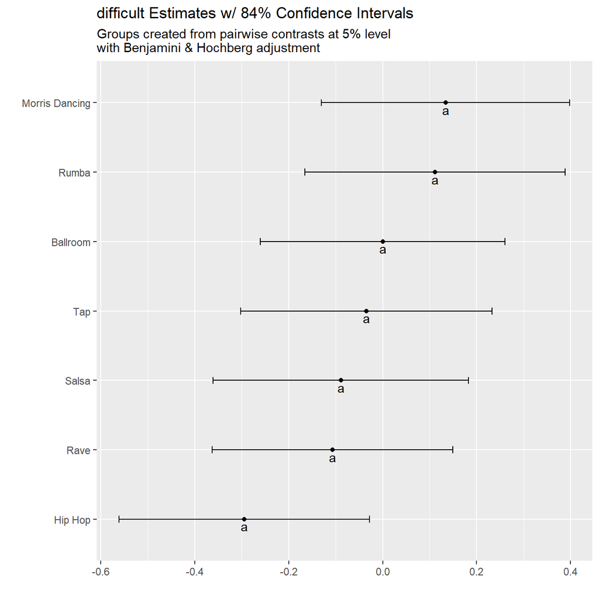

Table 5. 1 .2 difficult model parameter estimates

|  | Estimate | quasiSE | Group |
| --- | --- | --- | --- |
| Morris Dancing | 0.13 | 0.19 | a |
| Rumba | 0.11 | 0.20 | a |
| Ballroom | 0.00 | 0.19 | a |
| Tap | -0.03 | 0.19 | a |
| Salsa | -0.09 | 0.19 | a |
| Rave | -0.11 | 0.18 | a |
| Hip Hop | -0.29 | 0.19 | a |

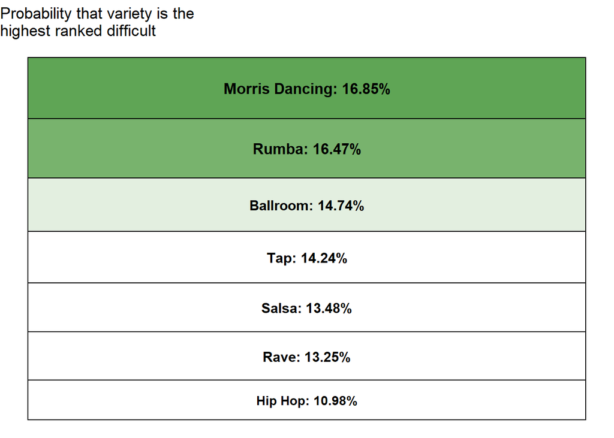

**What dance looks the best?**

Table 5.2.1

| model | logLikelihood | DF | Statistic | Pr(>Chisq) |
| --- | --- | --- | --- | --- |
| NULL | -252.6381 | 423 | NA | NA |
| mod_style | -251.6926 | 417 | 1.890871 | 0.92946 |

p=0.92946 , this suggests that there is not enough evidence to conclude that there are differences between varieties

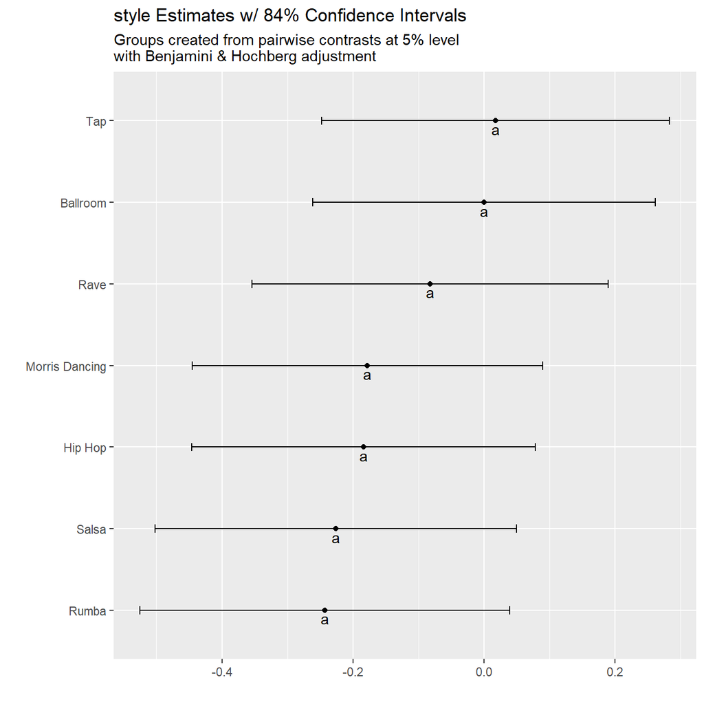

Table 5. 2 .2 style model parameter estimates

|  | Estimate | quasiSE | Group |
| --- | --- | --- | --- |
| Tap | 0.02 | 0.19 | a |
| Ballroom | 0.00 | 0.19 | a |
| Rave | -0.08 | 0.19 | a |
| Morris Dancing | -0.18 | 0.19 | a |
| Hip Hop | -0.18 | 0.19 | a |
| Salsa | -0.23 | 0.20 | a |
| Rumba | -0.24 | 0.20 | a |

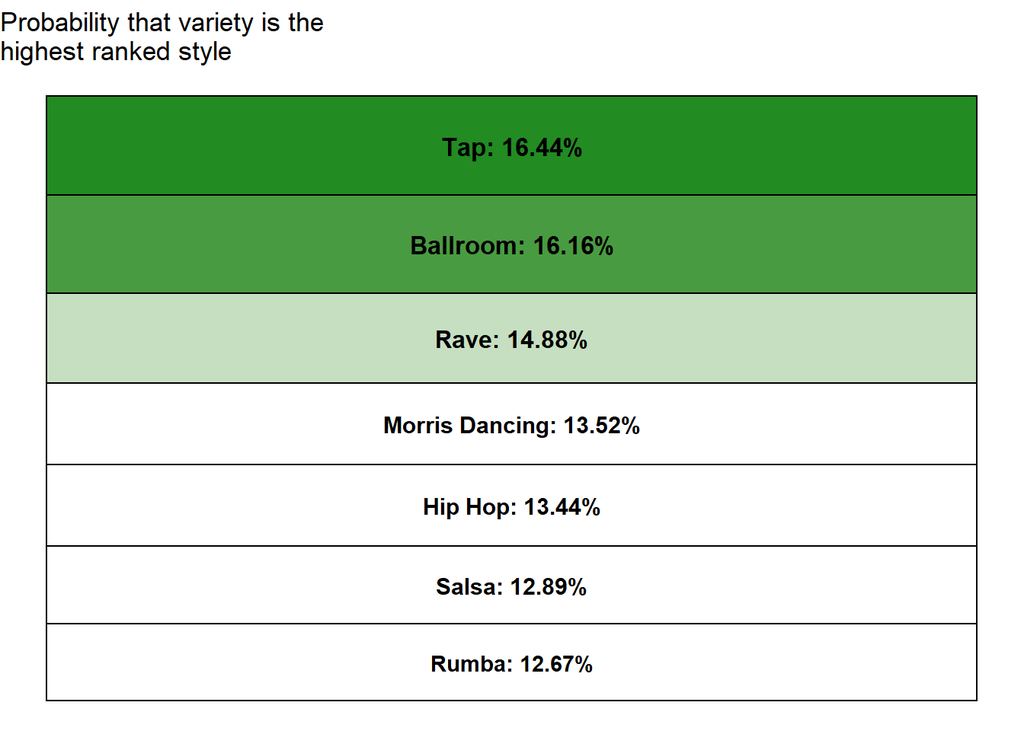

**What dance is the most fun?**

Table 5.3.1

| model | logLikelihood | DF | Statistic | Pr(>Chisq) |
| --- | --- | --- | --- | --- |
| NULL | -250.8463 | 420 | NA | NA |
| mod_fun | -247.2971 | 414 | 7.098535 | 0.31183 |

p=0.31183 , this suggests that there is not enough evidence to conclude that there are differences between varieties

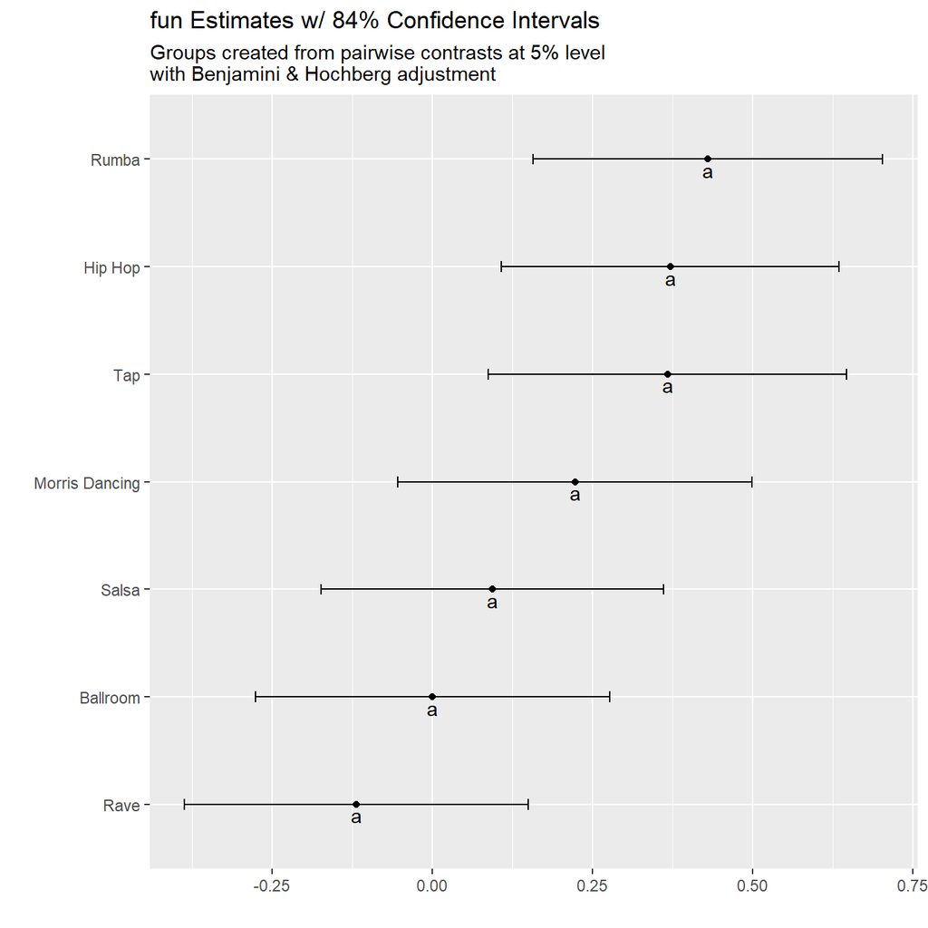

Table 5. 3 .2 fun model parameter estimates

|  | Estimate | quasiSE | Group |
| --- | --- | --- | --- |
| Rumba | 0.43 | 0.19 | a |
| Hip Hop | 0.37 | 0.19 | a |
| Tap | 0.37 | 0.20 | a |
| Morris Dancing | 0.22 | 0.20 | a |
| Salsa | 0.09 | 0.19 | a |
| Ballroom | 0.00 | 0.20 | a |
| Rave | -0.12 | 0.19 | a |

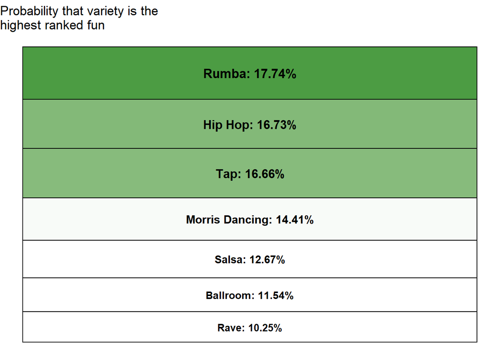